# Survival on the Titanic: A Data Driven Analysis

Leslie Ransehousen

2025-01-26

## Introduction

[figure not shown]

This report analyzes a Titanic dataset to explore patterns among passengers, focusing on factors influencing survival. The dataset contains information on passenger demographics, ticket details, and survival outcome that provided a good foundation for analysis.

## Load libraries and Data

```r
# Load required libraries
library(tidyverse)
library(scales)
library(ggthemes)
library(gridExtra)

# Load the Titanic dataset
titanic_data <- read.csv('data/titanic_clean.csv')

# Review the dataset
head(titanic_data)
```

```
##                            passenger_name       age survival_status
## 1 Dean, Miss. Elizabeth Gladys 'Millvina' 0.1666667             yes
## 2 Danbom, Master. Gilbert Sigvard Emanuel 0.3333333              no
## 3                   Tannūs, Master. As'ad 0.4166667             yes
## 4 Hämäläinen, Master. Viljo Unto Johannes 0.5833333             yes
## 5          Peacock, Master. Albert Edward 0.5833333              no
## 6           Baclini, Miss. Helene Barbara 0.7500000             yes
##   passenger_class gender ticket_fare embarkation_port
## 1             3rd female     20.1106                S
## 2             3rd   male     14.0800                S
## 3             3rd   male      8.1004                C
## 4             2nd   male     14.1000                S
## 5             3rd   male     13.1506                S
## 6             3rd female     19.0502                C
```

```r
summary(titanic_data)
```

```
##  passenger_name          age          survival_status    passenger_class
##  Length:1289        Min.   : 0.1667   Length:1289        Length:1289
##  Class :character   1st Qu.:21.0000   Class :character   Class :character
##  Mode  :character   Median :28.0000   Mode  :character   Mode  :character
##                     Mean   :29.5609
##                     3rd Qu.:38.0000
##                     Max.   :74.0000
##     gender           ticket_fare      embarkation_port
##  Length:1289        Min.   :  3.030   Length:1289
##  Class :character   1st Qu.:  7.181   Class :character
##  Mode  :character   Median : 14.100   Mode  :character
##                     Mean   : 33.446
##                     3rd Qu.: 31.071
##                     Max.   :512.061
```

```r
str(titanic_data)
```

```
## 'data.frame':    1289 obs. of  7 variables:
##  $ passenger_name  : chr  "Dean, Miss. Elizabeth Gladys 'Millvina'" "Danbom, Master. Gilbert Sigvard Emanuel" "Tannūs, Master. As'ad" "Hämäläinen, Master. Viljo Unto Johannes" ...
##  $ age             : num  0.167 0.333 0.417 0.583 0.583 ...
##  $ survival_status : chr  "yes" "no" "yes" "yes" ...
##  $ passenger_class : chr  "3rd" "3rd" "3rd" "2nd" ...
##  $ gender          : chr  "female" "male" "male" "male" ...
##  $ ticket_fare     : num  20.1 14.1 8.1 14.1 13.2 ...
##  $ embarkation_port: chr  "S" "S" "C" "S" ...
```

```r
colSums(is.na(titanic_data))
```

```
##   passenger_name              age  survival_status  passenger_class
##                0                0                0                0
##           gender      ticket_fare embarkation_port
##                0                0                0
```

## Plot 1 - Age and Survival by Gender

#### This visualizaton examines the relationship between passenger age and survival status, with gender indicated by color. It highlights potential trends in survival across age groups.

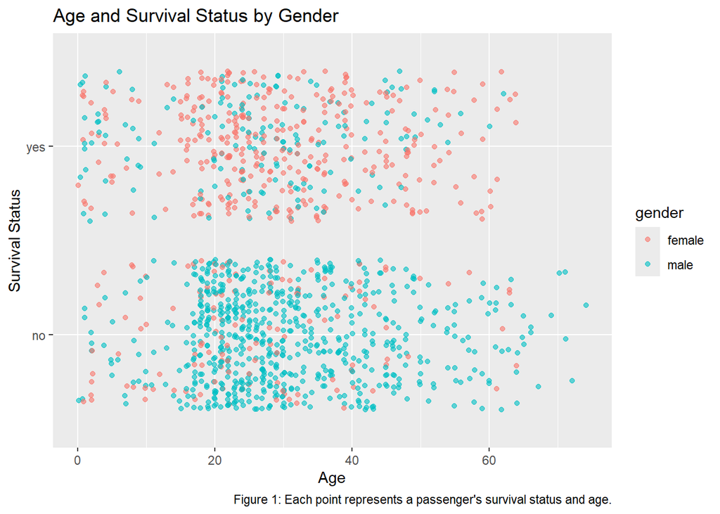

```r
ggplot(data = titanic_data, aes(x = age, y = survival_status, color = gender)) +
  geom_jitter(width = 0.2, alpha = 0.6) +
  labs(
    title = "Age and Survival Status by Gender",
    x = "Age",
    y = "Survival Status",
    caption = "Figure 1: Each point represents a passenger's survival status and age."
  )
```

## Plot 2 - Variation in Ticket Fares Across Passenger Classes on the Titanic

#### This plot visualizes how ticket fares varied across the passenger classes on the Titanic. It showcases the socioeconomic distinctions among passengers, with higher fares typically associated with first-class accommodations, reflecting disparites in wealth and amenities available to passengers in each class.

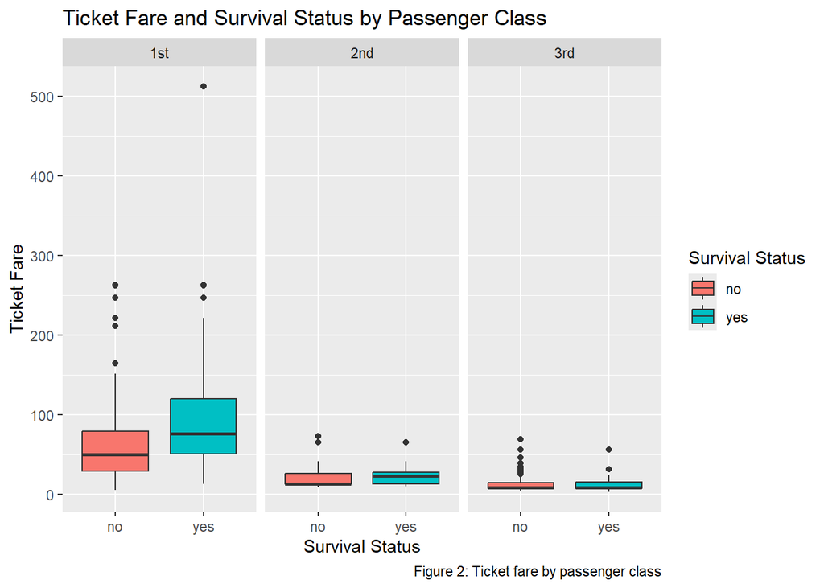

```r
ggplot(data = titanic_data, aes(x = survival_status, y = ticket_fare, fill = survival_status)) +
  geom_boxplot() +
  facet_wrap(~ passenger_class) +
  labs(
    title = "Ticket Fare and Survival Status by Passenger Class",
    x = "Survival Status",
    y = "Ticket Fare",
    fill = "Survival Status",
    caption = "Figure 2: Ticket fare by passenger class",
  )
```

## Plot 3 - Ticket Fare and Survival Status by Passenger Class

#### The plot compares ticket fares by survival status within each passenger class, displaying differences in survival outcomes based on socioeconomic factors.

[figure not shown]

```r
ggplot(data = titanic_data, aes(x = survival_status, y = ticket_fare, fill = survival_status)) +
  geom_boxplot() +
  facet_wrap(~ passenger_class) +
  labs(
    title = "Ticket Fare and Survival Status by Passenger Class",
    x = "Survival Status",
    y= "Ticket Fare",
    fill = "Survial Status",
    caption = "Figure 3: This plot compares the distribution of ticket fares between survivors and     non-survivors within each passenger class. It displays how ticket fare, as an indicator of         socioeconomic status, may have influenced survival outcomes on the Titanic."
  ) +
  scale_y_continuous(labels = scales::dollar_format(prefix = "$")) +
  theme_minimal()
```

## Plot 4 - Survival by Gender and Embarkation Port

#### This plot analyzes survival counts catagorized by gender and embarkation port, offering insights into how embarkation location impacted survival.

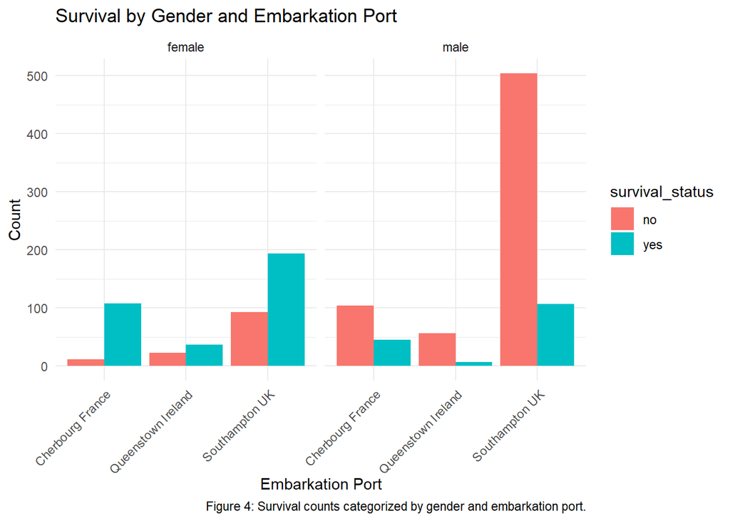

```r
# Relabel embarkation port codes with full names
titanic_data <- titanic_data %>%
  mutate(embarkation_port = recode(embarkation_port,
                                   "C" = "Cherbourg France",
                                   "Q" = "Queenstown Ireland",
                                   "S" = "Southampton UK"))

# Plot survival by gender and embarkation port
ggplot(data = titanic_data, aes(x = embarkation_port, fill = survival_status)) +
  geom_bar(position = "dodge") +
  facet_wrap(~ gender) +
  labs(
    title = "Survival by Gender and Embarkation Port",
    x = "Embarkation Port",
    y = "Count",
    caption = "Figure 4: Survival counts categorized by gender and embarkation port."
  ) +
  theme_minimal() +
  theme(axis.text.x = element_text(angle = 45, hjust = 1))
```

## Conclusion

These findings show how demographics, economic, and geographic factors intersected to influence survival outcomes during the Titanic tragedy.